# Early Global Covid-19 Report

Claudia Lopez & Vanessa Ortiz

2024-05-07

# Introduction

[This is the link to DataQuest.](https://www.dataquest.io/)

[This is the link to Kaggle.](https://www.kaggle.com/datasets/tanuprabhu/population-by-country-2020)

As an evolving planet and ever-evolving society, one thing has left a mark on the world . Covid-19 caused detrimental effects reaching all sides of the globe. In this data set, we take a dive into the relationship of Covid-19 and the negative toll that it took upon human health that is measured through deaths. We will visually showcase the pattern between the data sets, All while asking questions such as the correlation of Covid-19 and how they varied throughout each continent. Through these data sets we will have a greater understanding of the once critical problem that took the lives of many.

# Questions

- What are the Top 10 countries with the **Most** Covid-19 cases? – both the sum of cases and on average.
- What are the Top 5 countries with the **Least** Covid-19 cases?
- What is the relationship between hospitalization and deaths from Covid-19?
- Is there any correlation between the country population and Covid-19 cases?
- When was the peak of the most cases for Covid?

# Setting up

First lets load in the packages used.

```r
library(tidyverse) #main package used in order to manipulate data.
library(ggplot2) #package used for graphing.
library(lubridate) #this package was used to separate the dates into separate columns
library(scales) #this package was used to label the axis with percent
```

Next lets read the data sets we decided to use and create new variable names for them, as well as take a look at the unfiltered data.

```r
covid19_data <- read.csv("covid19.csv")
pop_data <- read.csv("population_by_country_2020.csv")

glimpse(covid19_data)
```

```
## Rows: 10,903
## Columns: 14
## $ Date                    <chr> "2020-01-20", "2020-01-22", "2020-01-22", "202…
## $ Continent_Name          <chr> "Asia", "North America", "North America", "Nor…
## $ Two_Letter_Country_Code <chr> "KR", "US", "US", "US", "US", "KR", "US", "US"…
## $ Country_Region          <chr> "South Korea", "United States", "United States…
## $ Province_State          <chr> "All States", "All States", "Washington", "All…
## $ positive                <int> 1, 1, 1, 1, 1, 2, 1, 1, 4, 0, 3, 0, 0, 0, 0, 1…
## $ hospitalized            <int> 0, 0, 0, 0, 0, 0, 0, 0, 0, 0, 0, 0, 0, 0, 0, 0…
## $ recovered               <int> 0, 0, 0, 0, 0, 0, 0, 0, 0, 0, 0, 0, 0, 0, 0, 0…
## $ death                   <int> 0, 0, 0, 0, 0, 0, 0, 0, 0, 0, 0, 0, 0, 0, 0, 0…
## $ total_tested            <int> 4, 1, 1, 1, 1, 27, 1, 1, 0, 0, 0, 0, 0, 0, 0, …
## $ active                  <int> 0, 0, 0, 0, 0, 0, 0, 0, 0, 0, 0, 0, 0, 0, 0, 0…
## $ hospitalizedCurr        <int> 0, 0, 0, 0, 0, 0, 0, 0, 0, 0, 0, 0, 0, 0, 0, 0…
## $ daily_tested            <int> 0, 0, 0, 0, 0, 5, 0, 0, 0, 0, 0, 0, 0, 0, 0, 0…
## $ daily_positive          <int> 0, 0, 0, 0, 0, 0, 0, 0, 0, 0, 0, 0, 0, 0, 0, 0…
```

```r
glimpse(pop_data)
```

```
## Rows: 235
## Columns: 11
## $ Country..or.dependency. <chr> "China", "India", "United States", "Indonesia"…
## $ Population..2020.       <int> 1440297825, 1382345085, 331341050, 274021604, …
## $ Yearly.Change           <chr> "0.39 %", "0.99 %", "0.59 %", "1.07 %", "2.00 …
## $ Net.Change              <int> 5540090, 13586631, 1937734, 2898047, 4327022, …
## $ Density..P.Km..         <int> 153, 464, 36, 151, 287, 25, 226, 1265, 9, 66, …
## $ Land.Area..Km..         <int> 9388211, 2973190, 9147420, 1811570, 770880, 83…
## $ Migrants..net.          <dbl> -348399, -532687, 954806, -98955, -233379, 212…
## $ Fert..Rate              <chr> "1.7", "2.2", "1.8", "2.3", "3.6", "1.7", "5.4…
## $ Med..Age                <chr> "38", "28", "38", "30", "23", "33", "18", "28"…
## $ Urban.Pop..             <chr> "61 %", "35 %", "83 %", "56 %", "35 %", "88 %"…
## $ World.Share             <chr> "18.47 %", "17.70 %", "4.25 %", "3.51 %", "2.8…
```

# Filtering the data

After viewing the information in these data sets, we decided to filter out any data we did not want to use. Notice how the date column in the ‘covid19_data’ has the year, month , and day combined. We realized it made it more difficult to filter out the information, therefore we created separate columns.

```r
glimpse(Final_covid19_data)
```

```
## Rows: 3,779
## Columns: 8
## $ date             <date> 2020-01-20, 2020-01-22, 2020-01-23, 2020-01-24, 2020…
## $ month            <dbl> 1, 1, 1, 1, 1, 1, 1, 1, 1, 1, 1, 1, 1, 1, 1, 1, 1, 1,…
## $ day              <dbl> 20, 22, 23, 24, 24, 25, 25, 25, 26, 26, 26, 26, 26, 2…
## $ Continent_Name   <chr> "Asia", "North America", "North America", "Asia", "No…
## $ Country_Region   <chr> "South Korea", "United States", "United States", "Sou…
## $ positive         <int> 1, 1, 1, 2, 1, 4, 1, 1, 4, 0, 3, 1, 1, 5, 0, 0, 4, 2,…
## $ death            <int> 0, 0, 0, 0, 0, 0, 0, 0, 0, 0, 0, 0, 0, 0, 0, 0, 0, 0,…
## $ hospitalizedCurr <int> 0, 0, 0, 0, 0, 0, 0, 0, 0, 0, 0, 0, 0, 0, 0, 0, 0, 0,…
```

# Data Analysis

## Top 10 Countries with Most Cases:

Thankfully the Covid 19 data set not only provided for a column with daily positive cases in each country but also a column for the total number of covid cases daily. Therefore in order to find the countries with the most cases, we filtered the countries with the hightest number of cases.

```
## # A tibble: 10 × 2
##    Country_Region   Cases
##    <chr>            <int>
##  1 United States  1783570
##  2 Russia          405843
##  3 Italy           232997
##  4 Spain           229422
##  5 Turkey          163942
##  6 United Kingdom  163418
##  7 Germany         157641
##  8 France          117324
##  9 Iran             99970
## 10 Brazil           92109
```

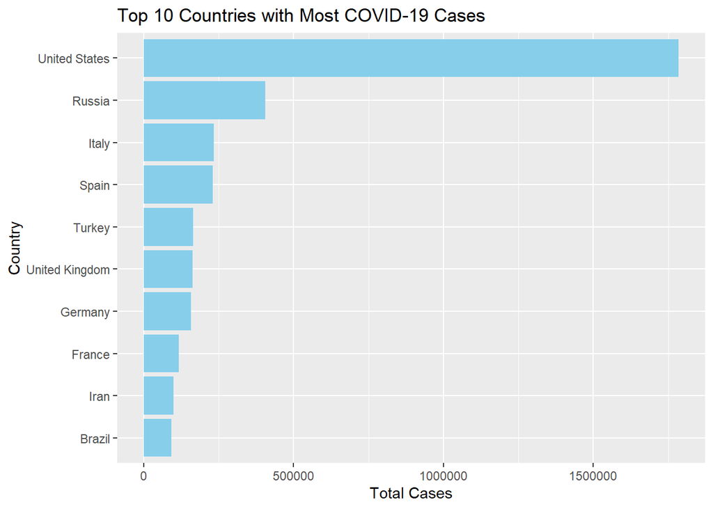

After filtering, we can clearly see the United States has the highest amount of cases with Russia and Italy following behind by over 1 million cases.

## Top 10 countries with least cases:

For this next question we used the same method as the previous question to find the countries with the least cases.

```
## # A tibble: 10 × 2
##    Country_Region      cases
##    <chr>               <int>
##  1 Ethiopia                0
##  2 Mauritius               0
##  3 North Korea             0
##  4 Grenada                18
##  5 Malawi                 41
##  6 Barbados               79
##  7 Mozambique             81
##  8 Uganda                 97
##  9 Nepal                  99
## 10 Trinidad and Tobago   116
```

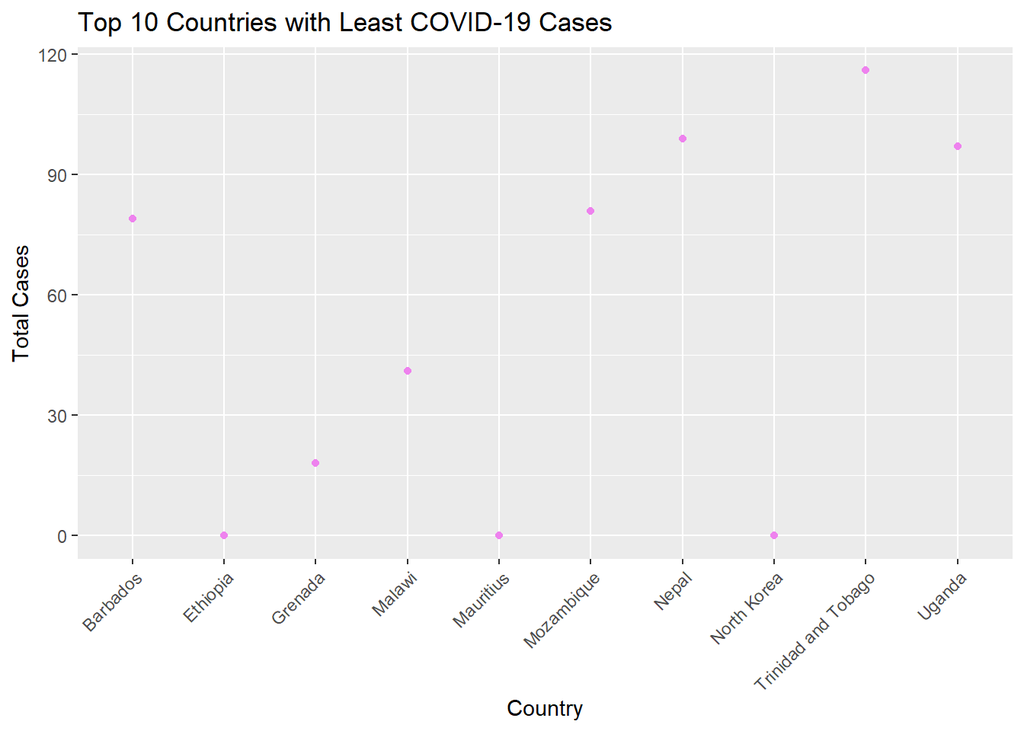

From here we can say that Ethiopia, Mauritius, and North Korea did not suffer from covid- 19 as there were no recorded cases according to the data. Seeing this data opened to more question that unfortunately could not be answered with this data set alone such as; - Was there anything these countries specifically did to limit their population from being affected by covid?

## What is the relationship between hospitalization and deaths from Covid-19?

For this next question, we created a separate data set to isolate the hospitalization and death columns. At this point in our analysis we realized there were some ilogical errors within the data. It is unknown whether the countries with 0 hospitalizations and deaths were actually zero, or not found information written as zero by the creator of the data set. Regardless we did our best to show the comparison.

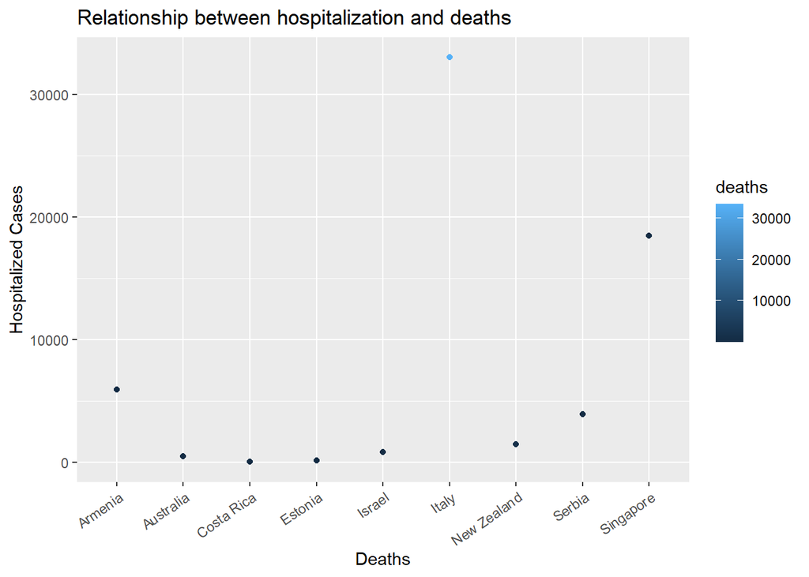

In this graph we can see how Italy not only had the highest hospitalized cases, but also the highest amount of deaths in comparison to the rest of the countries.

However, the graph above visually lacks to show a direct comparison to the deaths and hospitalized other than the variation in color.

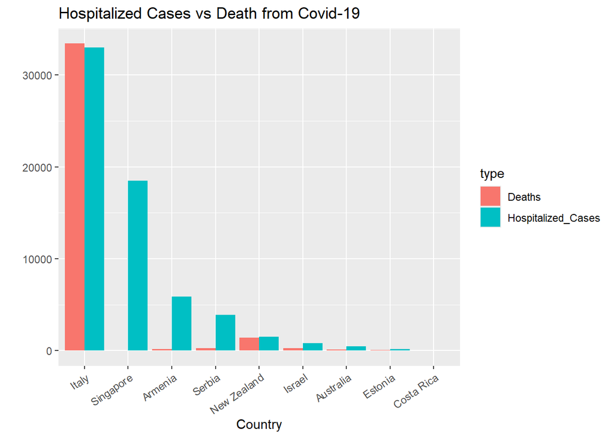

In this second graph it was much easier to fully visually compare both the amount of deaths and hospitalized cases for each country by providing graphs side by side. We can now see how Singapore had a relatively high number of hospitalized cases and yet no deaths. Additionally it seems that Italy and New Zealand were the only two countries with a number similarity in their deaths and hospitalized cases. Whereas the rest of the countries shown had a difference between them where there seem to be a low death count.

We noticed how previously the United States was listed as the country with the highest amount of covid cases, yet the United states had no hospitalized cases in the data. Therefore we wanted to explore the hospitalized cases and deaths individually to see if there were any other countries with “missing” data as well.

```
## # A tibble: 10 × 2
##    Country_Region   max
##    <chr>          <int>
##  1 Italy          33004
##  2 Singapore      18486
##  3 Armenia         5896
##  4 Serbia          3900
##  5 New Zealand     1481
##  6 Israel           825
##  7 Australia        458
##  8 Estonia          157
##  9 Iceland           44
## 10 Costa Rica        26
```

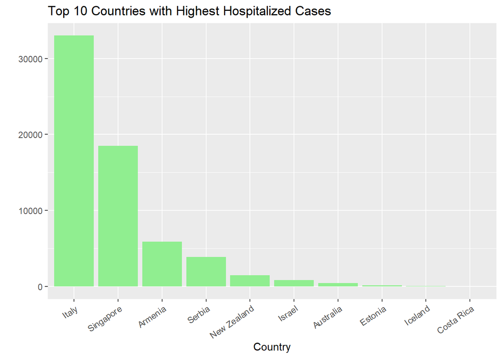

With the tibble of the Top 10 countries with the highest Hospitalized Cases, we can clearly see that Costa rica did have hospitalized cases. The reason it can been seen clearly on the graph is due to the low number in comparison to the other countries. A new Country seems to have appeared in this graph, Iceland also had some recorded hospitalized cases, meaning they did not have any deaths according to the data set.

Now lets take a look at countries with recorded deaths.

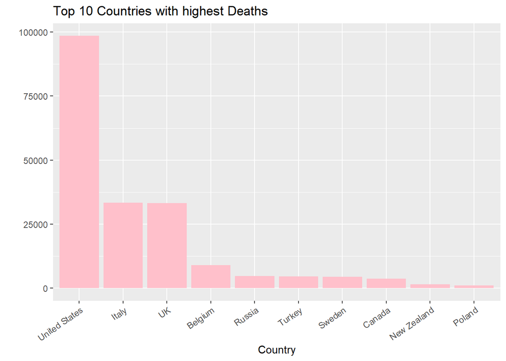

Here we see how many more countries do in fact have the number of deaths in the data set. The United states once again at the highest with nearly 100,000 deaths from covid.

## Correlation between the country population and covid-19 cases?

In order to find the correlation between population and covid-19 cases, we had to add another data set whoch gave us the 2020 population for each country. We joined the data sets and once again filtered the data we wanted to keep and placed it all into a variable for this question alone. We found it easier to show the percentage of how much of the population was affected in each country.

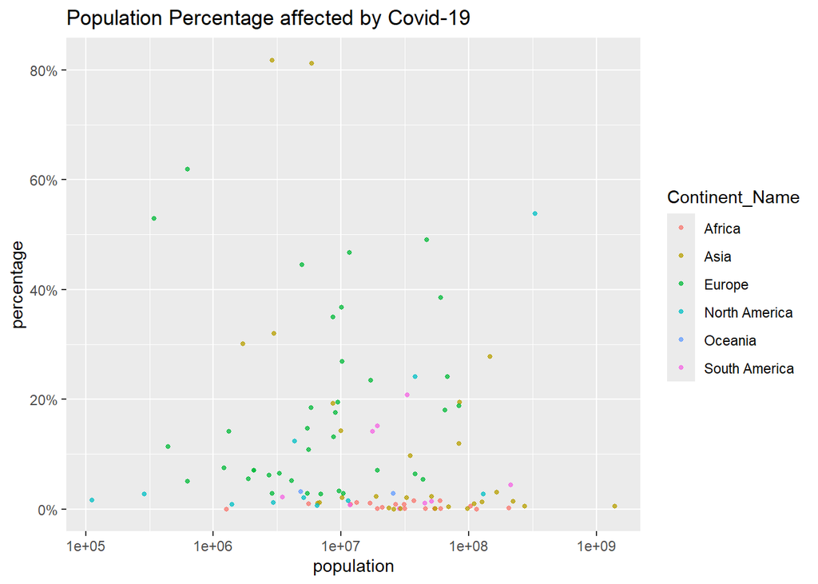

In this first graph, we have a very messy scatter plot showing all the countries and how much of their population was affected. Its important to note how the majority of African countries seem to be at the bottom. European countries seem to be the ones with the most variation amongst each other. It is still a bit difficult to differentiate them, so we decided to facet wrap the graph by continet.

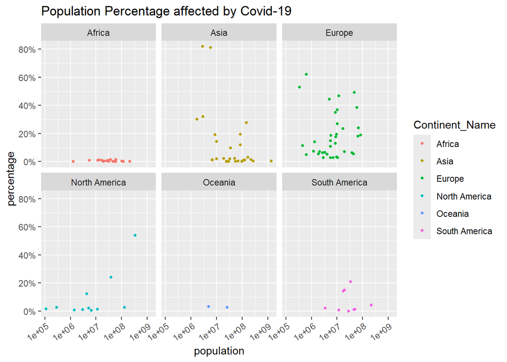

In this second graph, we can already visually distinguishg the continents thanks to the facet wrap. Interestingly, the African Countries are still overlapping one another. We were curious to see which countries were which, so we decided to create a graph for each one. We did not include Oceania as it only includes Australia and New Zealand.

#### Africa

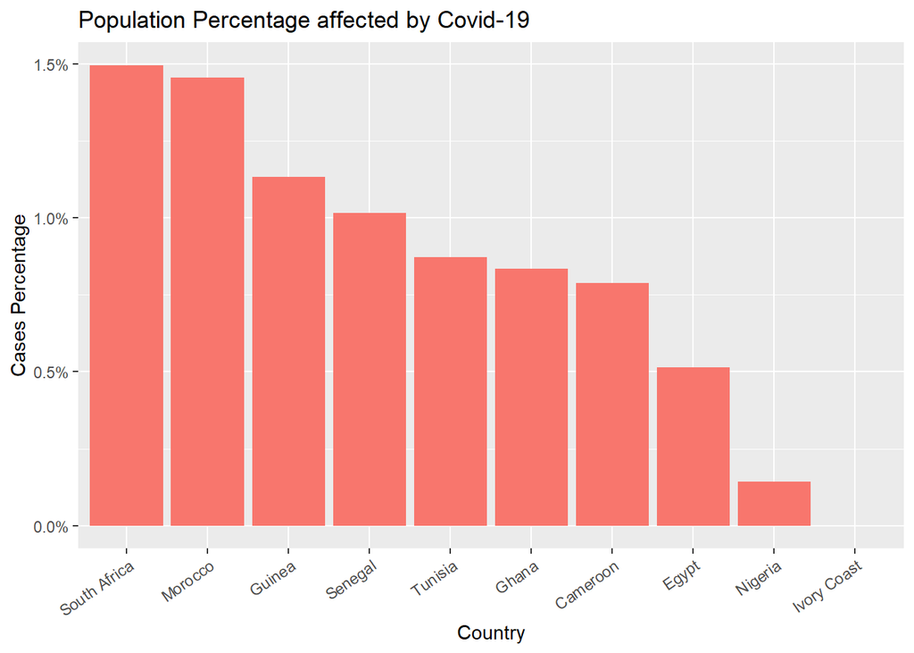

Overall, we can see how on average only 1% of the population was affected by Covid-19 in African countries. With South Africa having 1.5% of its population affected and Ivory Coast not having any Covid-19 Cases. If we look back to our previous question qith countries with the least Cases, Ivory Coast was not there. This could be a mistake that occurred from having added the 2020 population data set.

#### Asia

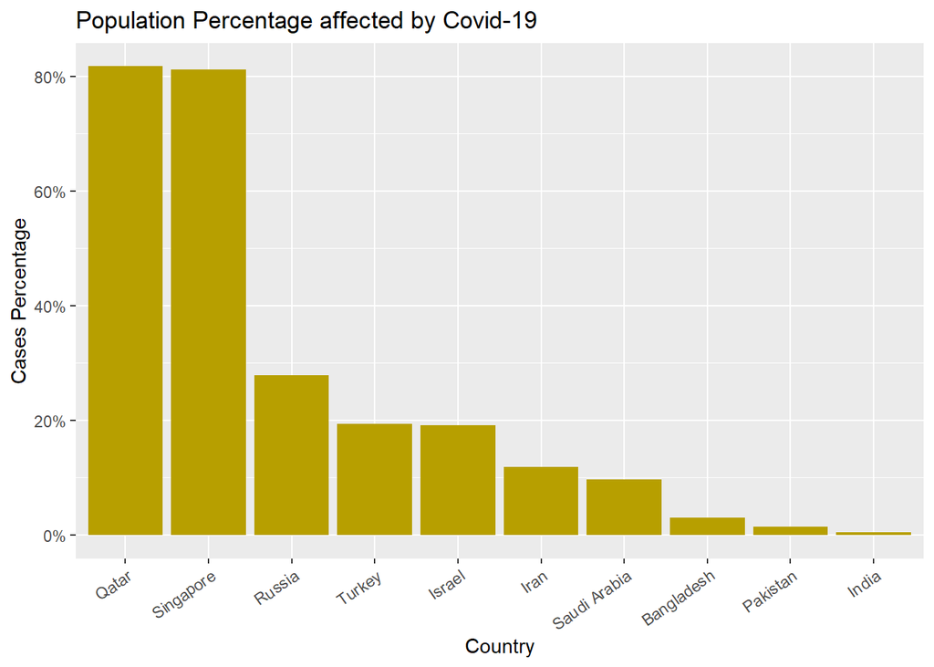

#### Europe

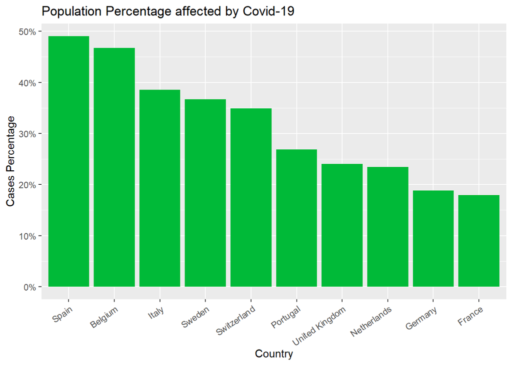

In the continent of Europe, they experience an average of 25% of their population affected by Covid-19. The countries most affected being Spain(almost 50%), Belgium (over 45%), and Italy (almost 40%).

#### North America

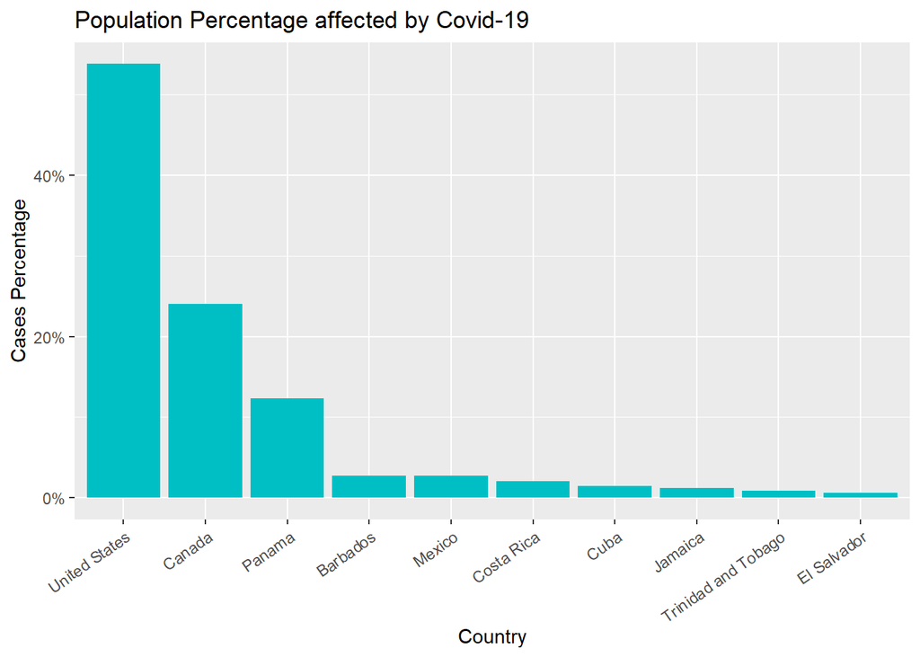

In North America, the country most affected early on in the Pandemic was the United States with over 45% of its population within the 6 month spam this data was collected. It may look as if the rest of the countries were not as affected, but this is only because of how high the percentage was in the United States.

#### South America

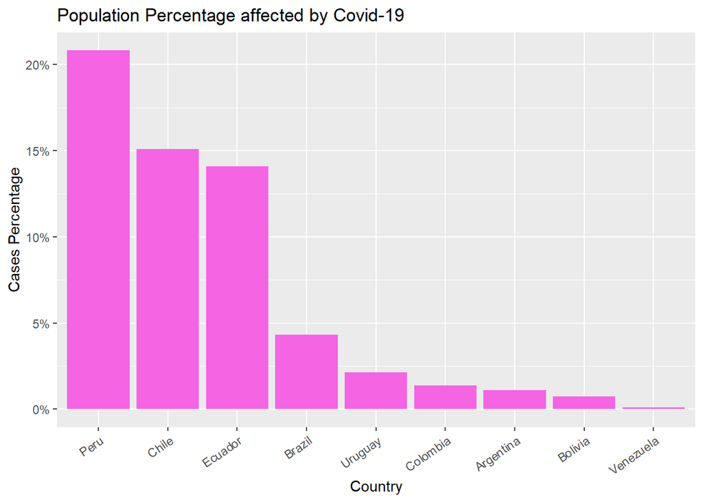

Lastly in South America, Peru was the most affected with over 20% of its population affected by Covid-19. This half of the Americas was not as affected as its sister North America.

## When was **peak** for Most Covid-19 Cases in Each Continent?:

For our last question we wanted to see the difference in the number of Covid-19 cases within the first 6 months of the pandemic.

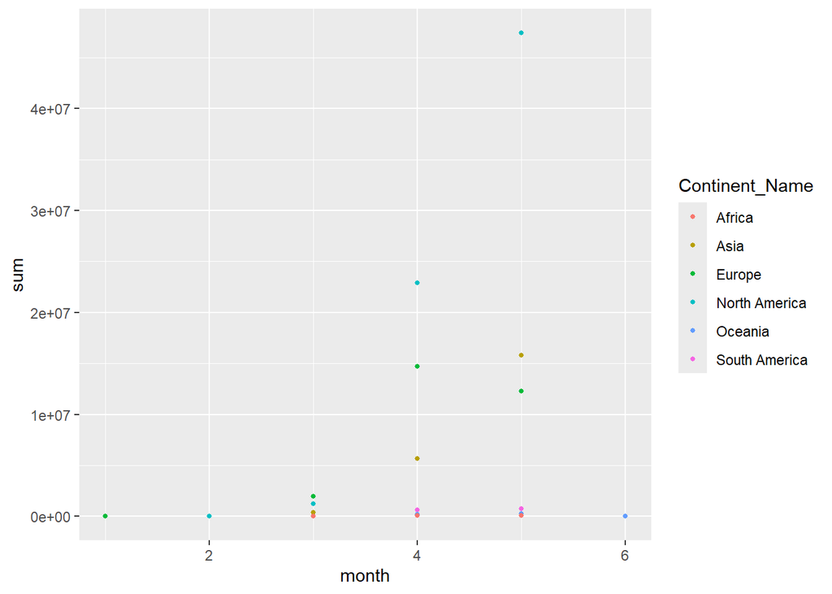

We can see how rapidly covid grew after the third month of the pandemic globaly. It is still difficult to distinguish the continents so we decided to facet wrap it again.

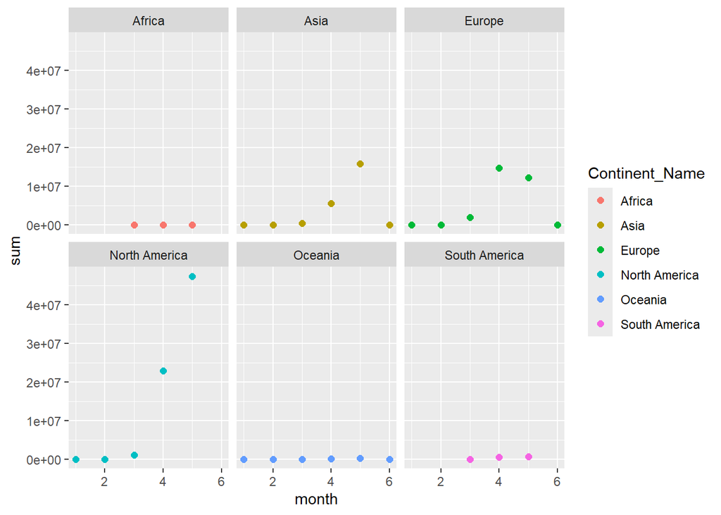